# Country Music

Examining the relationship between highly-played Spotify songs and overall happiness in different countries

Joey Hotz

March 10, 2022

# Introduction

Music is often thought of as one of the greatest cultural achievements which the human race has accomplished. From Stradivarius and Bach to Kanye West and Taylor Swift, music has continued to change and develop over time. With the advent of technology in the 21st Century, and the popularity of music streaming platforms, it is not a surprise that music is so prevalent in our daily lives. Beyond the fact that music is so easily accessible, it is also incredibly popular. Many people listen to music throughout the day, as they may find that it helps them to focus, or even improves their mood. Many people find that their mood changes alongside the mood of the music which they are listening to, which is why people may create playlists for specific emotions, such as a workout playlist or a “sad boi hours” playlist. Music, and in particular, the ability to play music easily at the touch of a button, presents an incredibly accessible way for people to change and regulate their emotions, as it can help you to be calm, or angry, or happy.

[Spotify](https://open.spotify.com/) is one of the largest and most popular music streaming apps in the world. The platform allows subscribers to easily play songs from a seemingly endless collection of music. On top of their vast collection of music, Spotify has hidden features within their API, such as their ‘advanced features’ of songs which are available on their platform. These advanced features which are available for songs on Spotify include measurements of whether or not a song is more instrumental or more vocal, how energetic the track is, and how happy a song is.

The metric which measures the ‘happiness’ level of a song is referred to as “valence” in the Spotify API. According to the [Spotify API’s documentation](https://developer.spotify.com/documentation/web-api/reference/#/operations/get-audio-features), a song’s valence is “A measure from 0.0 to 1.0 describing the musical positiveness conveyed by a track. Tracks with high valence sound more positive (e.g. happy, cheerful, euphoric), while tracks with low valence sound more negative (e.g. sad, depressed, angry).”

The [World Happiness Report](https://worldhappiness.report/ed/2021/) is an annually-published report which is written by members of the [United Nations Sustainable Development Solutions Network](https://www.unsdsn.org/). The report aims to classify the countries of the world based on how happy the citizens of the country are with their lives in the country. The SDSN collects their data by polling the citizens of the respective countries, and bases their happiness rankings on six primary explanatory factors; GDP per capita, social support, life expectancy, freedom to make life choices, generosity, and corruption.

The World Happiness Report is a well-regarded statistical survey which can be used as a numerical quantifiable metric for how happy citizens of a specific country are, with regard to the lives which they are able to lead in that country.

In this report, we seek to answer the following question: “*Is there a correlation between countries’ happiness levels and the happiness of the music which they listen to on Spotify?*”

To do this, we will collect the audio features of the most played tracks on Spotify in different countries around the world, and we will compare this information to the happiness index values in the World Happiness Report, to determine if there is a statistically significant relationship.

# Methods

The first steps of any statistical project are to collect the data which we want to analyze and make conclusions about, and to then explore and clean the data which we have collected, to ensure that our data fits our requirements.

## Data Collection

The SDSN publicly publishes a new World Happiness Report every year, and their organization ensures that their data is easily accessible. To collect the data from the most recent [World Happiness Report](https://worldhappiness.report/ed/2021/) (released in March 2021), we simply need to navigate the the 2021 report on the World Happiness Report website, and click the button labelled “Data for Figure 2.1”. In the 2021 World Happiness Report, Figure 2.1 represents the main table containing the SDSN’s findings, including the happiness index values which they computed for each country.

We can then download the dataset directly from the World Happiness Report’s website as a Microsoft Excel document, and read this data into R using the `readxl` library.

Table 1, which is shown below, depicts the top 7 rows of the data which were loaded into R from the downloaded Microsoft Excel document. In the World Happiness Report itself, as well as the data downloaded from their website, the rows in this table are sorted in descending order based on the happiness index of each country, which is listed under the “Ladder Score” column.

Table 1: Data from Table 2.1 of the 2021 World Happiness Report

| Country name | Regional indicator | Ladder score | Standard error of ladder score | upperwhisker | lowerwhisker | Logged GDP per capita | Social support | Healthy life expectancy | Freedom to make life choices | Generosity | Perceptions of corruption | Ladder score in Dystopia | Explained by: Log GDP per capita | Explained by: Social support | Explained by: Healthy life expectancy | Explained by: Freedom to make life choices | Explained by: Generosity | Explained by: Perceptions of corruption | Dystopia + residual |
| --- | --- | --- | --- | --- | --- | --- | --- | --- | --- | --- | --- | --- | --- | --- | --- | --- | --- | --- | --- |
| Finland | Western Europe | 7.8421 | 0.0316457 | 7.904126 | 7.780075 | 10.77520 | 0.9536034 | 72.00000 | 0.9492679 | -0.0977603 | 0.1858457 | 2.430343 | 1.446356 | 1.106191 | 0.7408238 | 0.6905766 | 0.1242005 | 0.4805240 | 3.253415 |
| Denmark | Western Europe | 7.6195 | 0.0346571 | 7.687428 | 7.551572 | 10.93318 | 0.9544095 | 72.69975 | 0.9456385 | 0.0301089 | 0.1788384 | 2.430343 | 1.501548 | 1.108008 | 0.7628624 | 0.6861603 | 0.2076146 | 0.4849927 | 2.868296 |
| Switzerland | Western Europe | 7.5715 | 0.0362430 | 7.642536 | 7.500464 | 11.11737 | 0.9417418 | 74.40010 | 0.9187882 | 0.0246292 | 0.2916985 | 2.430343 | 1.565899 | 1.079469 | 0.8164148 | 0.6534879 | 0.2040400 | 0.4130191 | 2.839148 |
| Iceland | Western Europe | 7.5539 | 0.0593734 | 7.670271 | 7.437528 | 10.87777 | 0.9829379 | 73.00000 | 0.9551228 | 0.1602740 | 0.6728647 | 2.430343 | 1.482190 | 1.172279 | 0.7723187 | 0.6977012 | 0.2925264 | 0.1699400 | 2.966945 |
| Netherlands | Western Europe | 7.4640 | 0.0273260 | 7.517559 | 7.410441 | 10.93181 | 0.9416009 | 72.40012 | 0.9131156 | 0.1754044 | 0.3379378 | 2.430343 | 1.501072 | 1.079151 | 0.7534254 | 0.6465853 | 0.3023966 | 0.3835311 | 2.797818 |
| Norway | Western Europe | 7.3925 | 0.0354486 | 7.461979 | 7.323021 | 11.05313 | 0.9544451 | 73.30001 | 0.9595884 | 0.0934256 | 0.2700278 | 2.430343 | 1.543455 | 1.108088 | 0.7817675 | 0.7031350 | 0.2489185 | 0.4268390 | 2.580301 |
| Sweden | Western Europe | 7.3627 | 0.0356996 | 7.432671 | 7.292729 | 10.86699 | 0.9338052 | 72.70005 | 0.9446041 | 0.0862229 | 0.2374600 | 2.430343 | 1.478426 | 1.061588 | 0.7628719 | 0.6849017 | 0.2442200 | 0.4476083 | 2.683093 |

Unlike the data which we collected from the 2021 edition of the World Happiness Report, the information relating to the most-played songs on Spotify in each country was significantly more difficult to collect and load into R.

To collect information about the most-played songs on Spotify in each of the countries, we scraped data from the [Spotify Charts](https://spotifycharts.com/regional/global/daily/latest) website in Python, using the `requests` and `BeautifulSoup` modules to collect the raw HTML code for the website, and coercing this data into a data frame using `pandas`.

The Spotify Charts website has information available for 72 countries, a majority of which are located in North America or Europe, and are primarily richer countries. Of the 72 countries with data available on the Spotify Charts website, only two of these countries (Nigeria and South Africa) are located in Sub-Saharan Africa, despite the fact that this is the geographic region with the largest number of countries, according to the World Happiness Report’s list of regions.

Within Spotify’s API, as well as the Spotify Charts website, each of these 72 countries has a corresponding two-letter country code. For example, Canada’s code is “ca”, and New Zealand’s code is “nz”. For any given country, the Spotify Charts link for the Top 200 songs in that country in a given week (Friday to Friday) is `https://spotifycharts.com/regional/[COUNTRY CODE]/weekly/[START OF WEEK]--[END OF WEEK]`, where the country code is the unique two-letter identifier, and “week start” and “week end” are the first and last days of the week respectively, each written in `YYYY-MM-DD` format.

To collect information from the Spotify Charts website, we defined a function to collect data from the Spotify Charts website given three inputs; a two-letter country code, and the starting and ending dates for the week. We then used a for-loop in Python to iterate through the 72 country codes which are usable on the Spotify Charts site, and we applied this function once for each of the country codes.

Table 2: Raw Data Collected from the Spotify Charts Website via Python

| Source | Position | Trend | Track | Streams | Country | Country_Code | Week_Start | Week_Ending |
| --- | --- | --- | --- | --- | --- | --- | --- | --- |
| <td class=“chart-table-image”> <a href=“https://open.spotify.com/track/02MWAaffLxlfxAUY7c5dvx” target="_blank“> <img src=”[https://i.scdn.co/image/ab67616d000048519e495fb707973f3390850eea"/>](https://… | <td class=“chart-table-position”>1</td> | <td class=“chart-table-trend”> <div class="chart-table-trend__icon“> <svg fill=”#3e3e40" version=“1.1” viewbox=“0 0 12 12” x=“0” y=“0”><rect height=“3” width=“12” y=“4.5”></rect></svg> </div> </td> | <td class=“chart-table-track”> <strong>Heat Waves</strong> <span>by Glass Animals</span> </td> | <td class=“chart-table-streams”>1,070,514</td> | Canada | ca | 2022-02-25 | 2022-03-04 |
| <td class=“chart-table-image”> <a href=“https://open.spotify.com/track/7rglLriMNBPAyuJOMGwi39” target="_blank“> <img src=”[https://i.scdn.co/image/ab67616d00004851523458c391fe8180a19a1069"/>](https://… | <td class=“chart-table-position”>2</td> | <td class=“chart-table-trend”> <div class="chart-table-trend__icon“> <svg fill=”#84bd00" version=“1.1” viewbox=“0 0 12 12” x=“0” y=“0”><polygon points=“0 9 12 9 6 3”></polygon></svg> </div> </td> | <td class=“chart-table-track”> <strong>Cold Heart - PNAU Remix</strong> <span>by Elton John, Dua Lipa</span> </td> | <td class=“chart-table-streams”>878,506</td> | Canada | ca | 2022-02-25 | 2022-03-04 |
| <td class=“chart-table-image”> <a href=“https://open.spotify.com/track/52xJxFP6TqMuO4Yt0eOkMz” target="_blank“> <img src=”[https://i.scdn.co/image/ab67616d00004851e1ac646ed6f25125e2a77229"/>](https://… | <td class=“chart-table-position”>3</td> | <td class=“chart-table-trend”> <div class="chart-table-trend__icon“> <svg fill=”#bd3200" version=“1.1” viewbox=“0 0 12 12” x=“0” y=“0”><polygon points=“12 3 0 3 6 9”></polygon></svg> </div> </td> | <td class=“chart-table-track”> <strong>We Don’t Talk About Bruno</strong> <span>by Carolina Gaitán - La Gaita, Mauro Castillo, Adassa, Rhenzy Feliz, Diane Guerrero, Stephanie Beatriz, Encanto - Cast</… | <td class=“chart-table-streams”>844,855</td> | Canada | ca | 2022-02-25 | 2022-03-04 |
| <td class=“chart-table-image”> <a href=“https://open.spotify.com/track/5PjdY0CKGZdEuoNab3yDmX” target="_blank“> <img src=”[https://i.scdn.co/image/ab67616d000048518e6551a2944764bc8e33a960"/>](https://… | <td class=“chart-table-position”>4</td> | <td class=“chart-table-trend”> <div class="chart-table-trend__icon“> <svg fill=”#3e3e40" version=“1.1” viewbox=“0 0 12 12” x=“0” y=“0”><rect height=“3” width=“12” y=“4.5”></rect></svg> </div> </td> | <td class=“chart-table-track”> <strong>STAY (with Justin Bieber)</strong> <span>by The Kid LAROI</span> </td> | <td class=“chart-table-streams”>832,044</td> | Canada | ca | 2022-02-25 | 2022-03-04 |
| <td class=“chart-table-image”> <a href=“https://open.spotify.com/track/5Z9KJZvQzH6PFmb8SNkxuk” target="_blank“> <img src=”[https://i.scdn.co/image/ab67616d00004851be82673b5f79d9658ec0a9fd"/>](https://… | <td class=“chart-table-position”>5</td> | <td class=“chart-table-trend”> <div class="chart-table-trend__icon“> <svg fill=”#84bd00" version=“1.1” viewbox=“0 0 12 12” x=“0” y=“0”><polygon points=“0 9 12 9 6 3”></polygon></svg> </div> </td> | <td class=“chart-table-track”> <strong>INDUSTRY BABY (feat. Jack Harlow)</strong> <span>by Lil Nas X</span> </td> | <td class=“chart-table-streams”>738,693</td> | Canada | ca | 2022-02-25 | 2022-03-04 |

## Data Cleaning

Tables 1 and 2, which were shown in the previous subsection, give us a quick glance at the data which we have collected from our sources and will be using in this report.

The data which was collected from the World Happiness Report is well-formatted, and does not require any immediate cleaning in order for the information in the table to be readable and usable. However, we will be ‘pruning’ the columns of that dataset, as a majority of the variables available to us in the World Happiness Report dataset are not required for our research purposes.

In particular, the only variables which we need from the World Happiness Report dataset are the first three columns; the name of the country, the geographic region where the country is located, and the country’s happiness score. In addition to these three variables, we will create a ‘ranking’ variable, where each country is ranked in descending order of happiness, according to the World Happiness Report data.

On the other hand, the Spotify data which we collected via web scraping in Python requires serious changes in order for the data to be viable. The most important alteration which we need to make to this dataset is to edit the contents of each cell, to select the necessary contents of the cell which are wrapped in the HTML code, without keeping the rest of the unneeded HTML in the table.

To remove this extraneous HTML code from our table, we will use the `stringr` library to remove particular regular expressions which match the unwanted HTML code in these cells.

Although our table of Spotify Charts data contains nine variables, only the first five columns require regular expressions to be mutated into a more usable form, as the four rightmost columns were inputted manually in Python during the web scraping process, and have been properly formatted in advance.

Of these five columns (Source, Position, Trend, Track, and Streams), only three of these columns must be fixed using regular expressions in order for us to use them in our research. These three columns are the Source, Position, and Streams columns.

The Trend column is not required to answer our research question, as we are only examining a ‘snapshot’ of time, and we do not need to concern ourselves with the overall week-to-week changes of these songs on the Top 200 songs chart.

Although the information in the Track column is useful, we can simply recover this information using the `spotifyr` package, which invokes the API created by Spotify for accessing data from the Spotify servers.

After our Spotify Charts data are cleaned, we will have a table which contains 7 variables per song. These variables are; the name of the country, the country’s two-letter code, the beginning and ending of the chosen week, the number of times the song was streamed in the chosen country during the given week, the song’s ranking on the Top 200 songs in the country for that week, and a link to the song on Spotify.

The first four of these seven desired variables are already formatted well in our current Spotify dataset, as they are the four variables which we manually included in the data while scraping with Python. The other three variables will require us to remove the excess HTML code from our data, as displayed in Table 2. We will remove this excess HTML using regular expressions.

Table 3: Spotify Charts Data, after Preliminary Cleaning

| country | country_code | begin | end | plays | song_rank | track_link |
| --- | --- | --- | --- | --- | --- | --- |
| Canada | ca | 2022-02-25 | 2022-03-04 | 1070514 | 1 | https://open.spotify.com/track/02MWAaffLxlfxAUY7c5dvx |
| Canada | ca | 2022-02-25 | 2022-03-04 | 878506 | 2 | https://open.spotify.com/track/7rglLriMNBPAyuJOMGwi39 |
| Canada | ca | 2022-02-25 | 2022-03-04 | 844855 | 3 | https://open.spotify.com/track/52xJxFP6TqMuO4Yt0eOkMz |
| Canada | ca | 2022-02-25 | 2022-03-04 | 832044 | 4 | https://open.spotify.com/track/5PjdY0CKGZdEuoNab3yDmX |
| Canada | ca | 2022-02-25 | 2022-03-04 | 738693 | 5 | https://open.spotify.com/track/5Z9KJZvQzH6PFmb8SNkxuk |

Table 3, which is shown above, depicts the observations in our cleaned dataset corresponding to the Top 5 most streamed songs on Spotify in Canada between February 25 and March 4, 2022.

At this point, our cleaning process included fixing up the text from the original data, removing unwanted HTML code from cells in the table, and removing excess variables which are unnecessary for answering our research question. The five songs shown in Table 3 are the same songs as those displayed in Table 2. There is a night-and-day difference between the elements of these two tables, despite the fact that the information is the same.

## API Data Collection

Now that we have cleaned the data which we collected from the Spotify Charts website, we can utilize the `spotifyr` package to collect additional data for each track, using the Spotify API.

In Spotify’s implementation of their platform, every track (songs, podcasts, etc.) has a unique identifier, which is part of the URL to that specific track on the Spotify client. The `spotifyr` package uses these identifiers in order to retrieve information about a particular track from the Spotify API.

To collect information about each of the tracks in the Top 200 lists, we will first determine the unique IDs for each of these tracks by using a regular expression to remove the Spotify domain from the track’s URL.

Once we have collected the track IDs for each of the tracks, we will then collect information about these tracks using Spotify’s API. For each track, we will collect three numeric values from the Spotify API corresponding to the given track; its ‘danceability’, ‘energy’, and ‘valence’.

## Data Grouping

In order to determine the average danceability, energy, and valence of the Top 200 songs for a particular country, we will use a weighted mean of each of these metrics, where the songs are weighted based on the number of streams which each track had in the given country during the specific time period.

Before we compute these weighted averages, we will check to see how many missing values there are among the 11 variables in our dataset, as missing values can cause our weighted mean computation to be error-prone if not accounted for.

Table 4: Counts of Variables in our Spotify Dataset

|  | Variable Type | Present Values | Missing Values |
| --- | --- | --- | --- |
| country | character | 14400 | 0 |
| country_code | character | 14400 | 0 |
| begin | double | 14400 | 0 |
| end | double | 14400 | 0 |
| plays | double | 14400 | 0 |
| song_rank | double | 14400 | 0 |
| track_link | character | 14400 | 0 |
| track_id | character | 14400 | 0 |
| danceability | double | 14397 | 3 |
| energy | double | 14397 | 3 |
| valence | double | 14397 | 3 |

As we see in Table 4 above, there are no missing values for a majority of the variables in our dataset. The only non-recorded values are three missing values in each of the danceability, energy, and valence columns in our Spotify dataset.

We will first examine the three tracks which had missing valences, as the valence of a track is more important to our results than the danceability or energy of a track. As Table 5 shows, the three tracks which do not have recorded valence values are also the three tracks which do not have danceability or energy values recorded either.

Table 5: Tracks which do not have recorded valence values

| country | country_code | begin | end | plays | song_rank | track_link | track_id | danceability | energy | valence |
| --- | --- | --- | --- | --- | --- | --- | --- | --- | --- | --- |
| Argentina | ar | 2022-02-25 | 2022-03-04 | 766614 | 44 | https://open.spotify.com/track/5saUoeceT2zau6ScmU77e6 | 5saUoeceT2zau6ScmU77e6 | NA | NA | NA |
| Italy | it | 2022-02-25 | 2022-03-04 | 684410 | 53 | https://open.spotify.com/track/02QztbIMzjvPNQnoECkydU | 02QztbIMzjvPNQnoECkydU | NA | NA | NA |
| Uruguay | uy | 2022-02-25 | 2022-03-04 | 28257 | 81 | https://open.spotify.com/track/5saUoeceT2zau6ScmU77e6 | 5saUoeceT2zau6ScmU77e6 | NA | NA | NA |

Due to the lack of clarity surrounding how Spotify computes the danceability, energy, and valence of a given track, it would be very difficult to reliably impute these missing values. Instead of imputation, to account for these missing values, we will simply remove these three tracks from our dataset before computing the weighted means of the danceability, energy, and valence levels of each country’s Top 200 songs on Spotify.

Although these three countries (Argentina, Italy, and Uruguay) will only have 199 tracks instead of 200 tracks, this is not a particularly large discrepancy, especially since these songs were not massively popular tracks in their respective countries.

Now that all of the missing values have been removed from the dataset, we can safely compute the weighted means for our three metrics, grouped by country. These three values are shown in Table 6.

Table 6: Weighted means of danceability, energy, and valence among the Top 200 Songs per country on Spotify

| country | mean_danceability | mean_energy | mean_valence |
| --- | --- | --- | --- |
| Argentina | 0.7305649 | 0.6688815 | 0.6551697 |
| Australia | 0.6559271 | 0.6612825 | 0.5141292 |
| Austria | 0.6806558 | 0.6762681 | 0.5194063 |
| Belarus | 0.6841963 | 0.6668493 | 0.4595995 |
| Belgium | 0.6708035 | 0.6573458 | 0.5310949 |
| Bolivia | 0.7239904 | 0.6766358 | 0.6260286 |
| Brazil | 0.6992066 | 0.7289616 | 0.6792344 |
| Bulgaria | 0.6825988 | 0.7031719 | 0.5351033 |
| Canada | 0.6755400 | 0.6443553 | 0.4936077 |
| Chile | 0.7654541 | 0.6959202 | 0.6362778 |
| Colombia | 0.7378438 | 0.6826002 | 0.6361242 |
| Costa Rica | 0.7215459 | 0.6353198 | 0.6101227 |
| Cyprus | 0.6818034 | 0.6526462 | 0.4845356 |
| Czech Republic | 0.6835192 | 0.6937636 | 0.5062472 |
| Denmark | 0.6924174 | 0.6505832 | 0.5633864 |
| Dominican Republic | 0.7443766 | 0.6919941 | 0.5761462 |
| Ecuador | 0.7426212 | 0.6807029 | 0.6090236 |
| Egypt | 0.7157028 | 0.6112053 | 0.5413517 |
| El Salvador | 0.7262493 | 0.6616731 | 0.5832978 |
| Estonia | 0.6429901 | 0.7027900 | 0.4674047 |
| Finland | 0.6529449 | 0.7127840 | 0.5339543 |
| France | 0.7327342 | 0.6613218 | 0.5412699 |
| Germany | 0.6997897 | 0.6624700 | 0.5078050 |
| Greece | 0.7226000 | 0.6702429 | 0.4996237 |
| Guatemala | 0.7124577 | 0.6380458 | 0.6063943 |
| Honduras | 0.7128377 | 0.6529583 | 0.5746582 |
| Hong Kong | 0.5862543 | 0.5675704 | 0.4433128 |
| Hungary | 0.7074072 | 0.6645674 | 0.5182870 |
| Iceland | 0.6552998 | 0.5236390 | 0.4694664 |
| India | 0.6660185 | 0.6257881 | 0.4925757 |
| Indonesia | 0.5628583 | 0.5083169 | 0.4047264 |
| Ireland | 0.6528951 | 0.6739207 | 0.5144107 |
| Israel | 0.6482851 | 0.5936377 | 0.4882465 |
| Italy | 0.6514532 | 0.6913623 | 0.5091042 |
| Japan | 0.5984204 | 0.7298657 | 0.5833426 |
| Kazakhstan | 0.6840741 | 0.6657929 | 0.4791853 |
| Latvia | 0.6646480 | 0.6669997 | 0.4586133 |
| Lithuania | 0.6617763 | 0.6571845 | 0.4655801 |
| Luxembourg | 0.6886505 | 0.6529272 | 0.5207501 |
| Malaysia | 0.5979358 | 0.5848258 | 0.4383599 |
| Mexico | 0.7068937 | 0.6309640 | 0.6312218 |
| Morocco | 0.6921049 | 0.5874032 | 0.5055644 |
| Netherlands | 0.6962831 | 0.6548411 | 0.5813321 |
| New Zealand | 0.6734161 | 0.6351290 | 0.5375649 |
| Nicaragua | 0.7207281 | 0.6612255 | 0.5765019 |
| Nigeria | 0.7603665 | 0.6625778 | 0.6325466 |
| Norway | 0.6425236 | 0.5951719 | 0.4756742 |
| Panama | 0.7167615 | 0.6829061 | 0.5842990 |
| Paraguay | 0.7177974 | 0.6945139 | 0.6487074 |
| Peru | 0.7365523 | 0.7004824 | 0.6187870 |
| Philippines | 0.6034857 | 0.5219030 | 0.4271533 |
| Poland | 0.7275911 | 0.6419235 | 0.5272818 |
| Portugal | 0.6900691 | 0.6472425 | 0.5663800 |
| Romania | 0.7213117 | 0.6580086 | 0.4970850 |
| Russia | 0.6860076 | 0.6799659 | 0.4736277 |
| Saudi Arabia | 0.6383755 | 0.6536338 | 0.5292986 |
| Singapore | 0.6110974 | 0.6023441 | 0.4679703 |
| Slovakia | 0.6905424 | 0.6825385 | 0.4875293 |
| South Africa | 0.7002589 | 0.5850207 | 0.4592435 |
| South Korea | 0.6434635 | 0.6672347 | 0.5297744 |
| Spain | 0.7398602 | 0.6991270 | 0.6218947 |
| Sweden | 0.6715828 | 0.6443019 | 0.5194846 |
| Switzerland | 0.6755041 | 0.6614996 | 0.5151935 |
| Taiwan | 0.5743900 | 0.5782357 | 0.4008411 |
| Thailand | 0.6547445 | 0.5967818 | 0.5424940 |
| Turkey | 0.6492160 | 0.6128975 | 0.4760636 |
| Ukraine | 0.6820126 | 0.6865280 | 0.4774423 |
| United Arab Emirates | 0.6547952 | 0.6292655 | 0.4827397 |
| United Kingdom | 0.6684967 | 0.6665605 | 0.5372348 |
| United States | 0.6662003 | 0.6244322 | 0.4709214 |
| Uruguay | 0.7373960 | 0.6752378 | 0.6668523 |
| Vietnam | 0.6650792 | 0.5540638 | 0.4642612 |

## Data Merging

Lastly, we can merge our datasets together, to create larger sets of data which we can use to analyze and answer our questions.

We will create two new larger sets of data through merging the Spotify Charts information and the World Happiness Report data. One of these new datasets will be a track-based dataset, created by combining our larger Spotify dataset which we cleaned with the World Happiness Report’s data.

The second dataset will contain country-based information, and we will create it by merging the weighted means by country shown in Table 6, and the World Happiness Report data.

Before we merge the tables together, we have to ensure that this merging process will be successful. The Spotify Charts website might use different names for countries than the World Happiness Report, we will need to determine if there are any countries whose names may be different in these two datasets. To do this, we will determine which country names are present in the Spotify Charts dataset (shown in Table 6) and are not present in the happiness index.

We can do this by taking the intersection of all country names which are present in both datasets, and subtracting this intersection from the set of country names present in the Spotify Charts data.

```r
setdiff(weighted_means_by_country$country, intersect(weighted_means_by_country$country, happiness_small$country))
```

```
## [1] "Hong Kong" "Taiwan"
```

From the output above, we see that Hong Kong and Taiwan are the only countries which have observations in the Spotify Charts data but not present in the World Happiness Report’s dataset.

Examining the list of countries in the World Happiness Report data, we see that there are observations for both of these countries recorded in the World Happiness Report. However, Hong Kong is referred to as “Hong Kong S.A.R. of China”, and Taiwan is referred to as “Taiwan Province of China”. If we replace these names in the World Happiness Report data, we will be able to properly merge our datasets together.

Table 7: Example of per-track data, using the Top 5 songs from Canada

| country | country_code | begin | end | plays | song_rank | track_link | track_id | danceability | energy | valence | region | happiness | happiness_rank |
| --- | --- | --- | --- | --- | --- | --- | --- | --- | --- | --- | --- | --- | --- |
| Canada | ca | 2022-02-25 | 2022-03-04 | 1070514 | 1 | https://open.spotify.com/track/02MWAaffLxlfxAUY7c5dvx | 02MWAaffLxlfxAUY7c5dvx | 0.761 | 0.525 | 0.531 | North America and ANZ | 7.1033 | 14 |
| Canada | ca | 2022-02-25 | 2022-03-04 | 878506 | 2 | https://open.spotify.com/track/7rglLriMNBPAyuJOMGwi39 | 7rglLriMNBPAyuJOMGwi39 | 0.795 | 0.800 | 0.934 | North America and ANZ | 7.1033 | 14 |
| Canada | ca | 2022-02-25 | 2022-03-04 | 844855 | 3 | https://open.spotify.com/track/52xJxFP6TqMuO4Yt0eOkMz | 52xJxFP6TqMuO4Yt0eOkMz | 0.577 | 0.450 | 0.830 | North America and ANZ | 7.1033 | 14 |
| Canada | ca | 2022-02-25 | 2022-03-04 | 832044 | 4 | https://open.spotify.com/track/5PjdY0CKGZdEuoNab3yDmX | 5PjdY0CKGZdEuoNab3yDmX | 0.591 | 0.764 | 0.478 | North America and ANZ | 7.1033 | 14 |
| Canada | ca | 2022-02-25 | 2022-03-04 | 738693 | 5 | https://open.spotify.com/track/5Z9KJZvQzH6PFmb8SNkxuk | 5Z9KJZvQzH6PFmb8SNkxuk | 0.741 | 0.691 | 0.892 | North America and ANZ | 7.1033 | 14 |

## Data Exploration

Now that our tables have been thoroughly cleaned and merged, we can begin to explore the data which we collected in greater detail.

First, we will create a histogram for the song valence values and happiness index values in our dataset, as these are the two main variables which we are concerned with examining in this report.

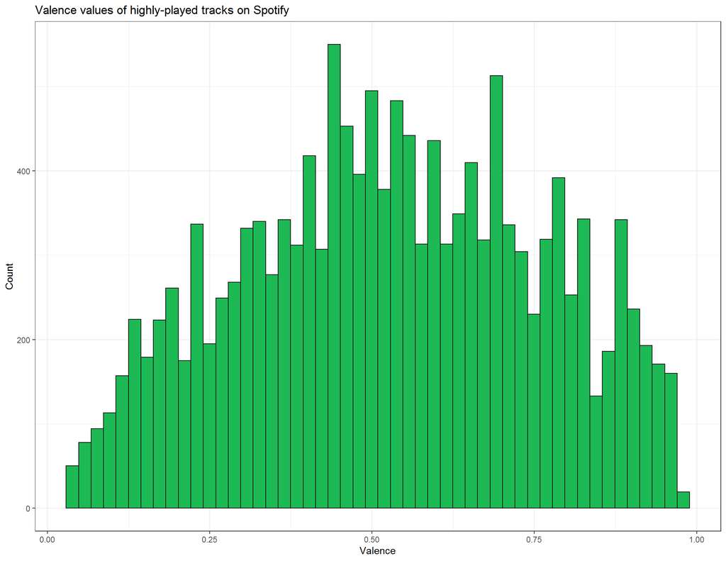

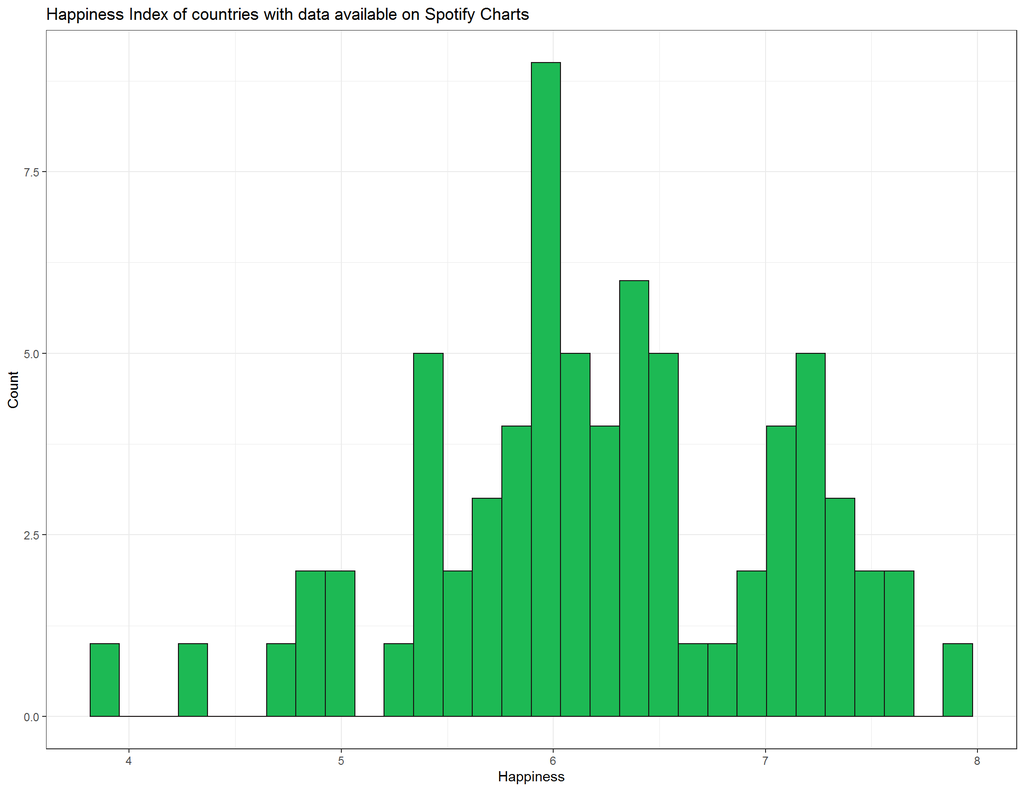

In the chart above, the values of the happiness index (per the World Happiness Report) appear to be roughly Normally distributed when we exclusively look at the happiness index values for the 72 countries who have data available on Spotify Charts. However, these countries may not be representative of all of the countries in the world.

One of the variables available for each country in the World Happiness Report data is the region where that country is located. We can use the data to count the number of countries in each of these region, as well as the number of countries per region which are present and not recorded in the Spotify data.

These regions are determined based on cultural and geographical similarities between groups of countries, instead of geography alone, which is why there are some strange regions, such as Mexico not being listed with North America, and the existence of the ‘Commonwealth of Independent States’ region, which does not have a particular geographic location.

Table 8: Number of countries with and without Top 200 Spotify Data per region

|  | Total Countries | Countries with Spotify Data | Countries without Spotify Data |
| --- | --- | --- | --- |
| Central and Eastern Europe | 17 | 9 | 8 |
| Commonwealth of Independent States | 12 | 4 | 8 |
| East Asia | 6 | 4 | 2 |
| Latin America and Caribbean | 20 | 17 | 3 |
| Middle East and North Africa | 17 | 6 | 11 |
| North America and ANZ | 4 | 4 | 0 |
| South Asia | 7 | 1 | 6 |
| Southeast Asia | 9 | 6 | 3 |
| Sub-Saharan Africa | 36 | 2 | 34 |
| Western Europe | 21 | 19 | 2 |

The table above shows clear discrepancies in the availability of Spotify data with regard to the different regions of the world. Some areas, such as Western Europe and North America have Spotify data available for almost every single country, whereas only 2 of the 36 countries in Sub-Saharan Africa have data available on the Spotify Charts website.

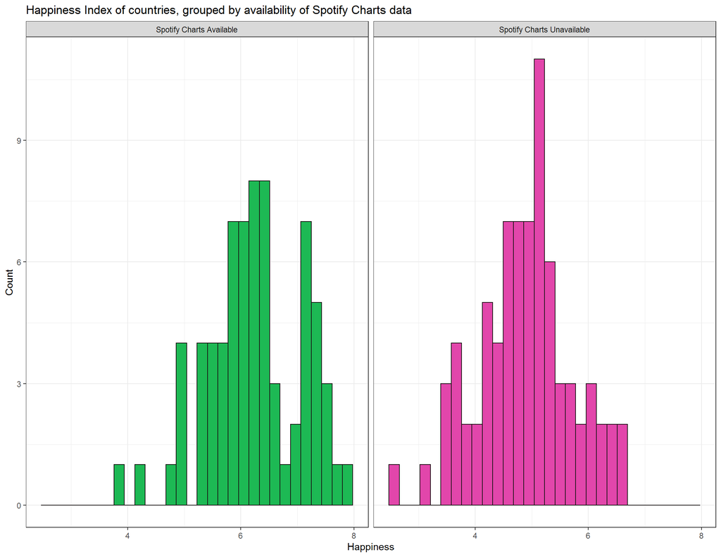

As we can see in the histogram above, there is a clear discrepancy between the happiness index of countries which have data available on the Spotify Charts website and the countries which do not have this data readily available.

# Preliminary Results

The key question which guided our research was “is there a correlation between countries’ happiness levels and the happiness of the music which they listen to on Spotify?”

To answer this question, we will compare each country’s average Spotify valence to their happiness index value.

First, we will create numerical summaries for the two major variables which we are examining in this report; the mean valence of highly-played songs in each country and the overall happiness of citizens in those countries.

Table 9: Numerical Summary of Track Valences

| Average Track Valence | Standard Deviation of Track Valence | Minimum Valence | 1st Quartile | Median Valence | 3rd Quartile | Maximum Valence |
| --- | --- | --- | --- | --- | --- | --- |
| 0.528 | 0.228 | 0.035 | 0.359 | 0.528 | 0.703 | 0.976 |

Table 10: Numerical Summary of Happiness Index Values

| Average Happiness Index | Standard Deviation of Happiness Index | Minimum Happiness Index | 1st Quartile | Median Happiness Index | 3rd Quartile | Maximum Happiness Index |
| --- | --- | --- | --- | --- | --- | --- |
| 6.228 | 0.828 | 3.819 | 5.723 | 6.172 | 6.965 | 7.842 |

Next, we will create a table with an overview of the mean valence, energy, and danceability of the highest-played tracks in each country, alongside information about the country which was gathered in the World Happiness Report.

Table 11: Spotify Top songs and World Happiness Data, aggregated by country

| country | mean_danceability | mean_energy | mean_valence | region | happiness | happiness_rank |
| --- | --- | --- | --- | --- | --- | --- |
| Argentina | 0.7305649 | 0.6688815 | 0.6551697 | Latin America and Caribbean | 5.9293 | 57 |
| Australia | 0.6559271 | 0.6612825 | 0.5141292 | North America and ANZ | 7.1835 | 11 |
| Austria | 0.6806558 | 0.6762681 | 0.5194063 | Western Europe | 7.2678 | 10 |
| Belarus | 0.6841963 | 0.6668493 | 0.4595995 | Commonwealth of Independent States | 5.5335 | 75 |
| Belgium | 0.6708035 | 0.6573458 | 0.5310949 | Western Europe | 6.8340 | 20 |
| Bolivia | 0.7239904 | 0.6766358 | 0.6260286 | Latin America and Caribbean | 5.7159 | 69 |
| Brazil | 0.6992066 | 0.7289616 | 0.6792344 | Latin America and Caribbean | 6.3301 | 35 |
| Bulgaria | 0.6825988 | 0.7031719 | 0.5351033 | Central and Eastern Europe | 5.2655 | 88 |
| Canada | 0.6755400 | 0.6443553 | 0.4936077 | North America and ANZ | 7.1033 | 14 |
| Chile | 0.7654541 | 0.6959202 | 0.6362778 | Latin America and Caribbean | 6.1719 | 43 |
| Colombia | 0.7378438 | 0.6826002 | 0.6361242 | Latin America and Caribbean | 6.0124 | 52 |
| Costa Rica | 0.7215459 | 0.6353198 | 0.6101227 | Latin America and Caribbean | 7.0694 | 16 |
| Cyprus | 0.6818034 | 0.6526462 | 0.4845356 | Western Europe | 6.2235 | 39 |
| Czech Republic | 0.6835192 | 0.6937636 | 0.5062472 | Central and Eastern Europe | 6.9647 | 18 |
| Denmark | 0.6924174 | 0.6505832 | 0.5633864 | Western Europe | 7.6195 | 2 |
| Dominican Republic | 0.7443766 | 0.6919941 | 0.5761462 | Latin America and Caribbean | 5.5451 | 73 |
| Ecuador | 0.7426212 | 0.6807029 | 0.6090236 | Latin America and Caribbean | 5.7640 | 66 |
| Egypt | 0.7157028 | 0.6112053 | 0.5413517 | Middle East and North Africa | 4.2827 | 132 |
| El Salvador | 0.7262493 | 0.6616731 | 0.5832978 | Latin America and Caribbean | 6.0605 | 49 |
| Estonia | 0.6429901 | 0.7027900 | 0.4674047 | Central and Eastern Europe | 6.1888 | 40 |
| Finland | 0.6529449 | 0.7127840 | 0.5339543 | Western Europe | 7.8421 | 1 |
| France | 0.7327342 | 0.6613218 | 0.5412699 | Western Europe | 6.6899 | 21 |
| Germany | 0.6997897 | 0.6624700 | 0.5078050 | Western Europe | 7.1545 | 13 |
| Greece | 0.7226000 | 0.6702429 | 0.4996237 | Western Europe | 5.7226 | 68 |
| Guatemala | 0.7124577 | 0.6380458 | 0.6063943 | Latin America and Caribbean | 6.4345 | 30 |
| Honduras | 0.7128377 | 0.6529583 | 0.5746582 | Latin America and Caribbean | 5.9192 | 59 |
| Hong Kong | 0.5862543 | 0.5675704 | 0.4433128 | East Asia | 5.4767 | 77 |
| Hungary | 0.7074072 | 0.6645674 | 0.5182870 | Central and Eastern Europe | 5.9916 | 53 |
| Iceland | 0.6552998 | 0.5236390 | 0.4694664 | Western Europe | 7.5539 | 4 |
| India | 0.6660185 | 0.6257881 | 0.4925757 | South Asia | 3.8189 | 139 |
| Indonesia | 0.5628583 | 0.5083169 | 0.4047264 | Southeast Asia | 5.3445 | 82 |
| Ireland | 0.6528951 | 0.6739207 | 0.5144107 | Western Europe | 7.0853 | 15 |
| Israel | 0.6482851 | 0.5936377 | 0.4882465 | Middle East and North Africa | 7.1571 | 12 |
| Italy | 0.6514532 | 0.6913623 | 0.5091042 | Western Europe | 6.4831 | 28 |
| Japan | 0.5984204 | 0.7298657 | 0.5833426 | East Asia | 5.9405 | 56 |
| Kazakhstan | 0.6840741 | 0.6657929 | 0.4791853 | Commonwealth of Independent States | 6.1518 | 45 |
| Latvia | 0.6646480 | 0.6669997 | 0.4586133 | Central and Eastern Europe | 6.0320 | 51 |
| Lithuania | 0.6617763 | 0.6571845 | 0.4655801 | Central and Eastern Europe | 6.2554 | 38 |
| Luxembourg | 0.6886505 | 0.6529272 | 0.5207501 | Western Europe | 7.3244 | 8 |
| Malaysia | 0.5979358 | 0.5848258 | 0.4383599 | Southeast Asia | 5.3843 | 81 |
| Mexico | 0.7068937 | 0.6309640 | 0.6312218 | Latin America and Caribbean | 6.3168 | 36 |
| Morocco | 0.6921049 | 0.5874032 | 0.5055644 | Middle East and North Africa | 4.9180 | 106 |
| Netherlands | 0.6962831 | 0.6548411 | 0.5813321 | Western Europe | 7.4640 | 5 |
| New Zealand | 0.6734161 | 0.6351290 | 0.5375649 | North America and ANZ | 7.2766 | 9 |
| Nicaragua | 0.7207281 | 0.6612255 | 0.5765019 | Latin America and Caribbean | 5.9721 | 55 |
| Nigeria | 0.7603665 | 0.6625778 | 0.6325466 | Sub-Saharan Africa | 4.7593 | 116 |
| Norway | 0.6425236 | 0.5951719 | 0.4756742 | Western Europe | 7.3925 | 6 |
| Panama | 0.7167615 | 0.6829061 | 0.5842990 | Latin America and Caribbean | 6.1796 | 41 |
| Paraguay | 0.7177974 | 0.6945139 | 0.6487074 | Latin America and Caribbean | 5.6526 | 71 |
| Peru | 0.7365523 | 0.7004824 | 0.6187870 | Latin America and Caribbean | 5.8396 | 63 |
| Philippines | 0.6034857 | 0.5219030 | 0.4271533 | Southeast Asia | 5.8802 | 61 |
| Poland | 0.7275911 | 0.6419235 | 0.5272818 | Central and Eastern Europe | 6.1661 | 44 |
| Portugal | 0.6900691 | 0.6472425 | 0.5663800 | Western Europe | 5.9290 | 58 |
| Romania | 0.7213117 | 0.6580086 | 0.4970850 | Central and Eastern Europe | 6.1400 | 46 |
| Russia | 0.6860076 | 0.6799659 | 0.4736277 | Commonwealth of Independent States | 5.4772 | 76 |
| Saudi Arabia | 0.6383755 | 0.6536338 | 0.5292986 | Middle East and North Africa | 6.4940 | 26 |
| Singapore | 0.6110974 | 0.6023441 | 0.4679703 | Southeast Asia | 6.3765 | 32 |
| Slovakia | 0.6905424 | 0.6825385 | 0.4875293 | Central and Eastern Europe | 6.3309 | 34 |
| South Africa | 0.7002589 | 0.5850207 | 0.4592435 | Sub-Saharan Africa | 4.9564 | 103 |
| South Korea | 0.6434635 | 0.6672347 | 0.5297744 | East Asia | 5.8455 | 62 |
| Spain | 0.7398602 | 0.6991270 | 0.6218947 | Western Europe | 6.4907 | 27 |
| Sweden | 0.6715828 | 0.6443019 | 0.5194846 | Western Europe | 7.3627 | 7 |
| Switzerland | 0.6755041 | 0.6614996 | 0.5151935 | Western Europe | 7.5715 | 3 |
| Taiwan | 0.5743900 | 0.5782357 | 0.4008411 | East Asia | 6.5844 | 24 |
| Thailand | 0.6547445 | 0.5967818 | 0.5424940 | Southeast Asia | 5.9847 | 54 |
| Turkey | 0.6492160 | 0.6128975 | 0.4760636 | Middle East and North Africa | 4.9476 | 104 |
| Ukraine | 0.6820126 | 0.6865280 | 0.4774423 | Commonwealth of Independent States | 4.8748 | 110 |
| United Arab Emirates | 0.6547952 | 0.6292655 | 0.4827397 | Middle East and North Africa | 6.5605 | 25 |
| United Kingdom | 0.6684967 | 0.6665605 | 0.5372348 | Western Europe | 7.0636 | 17 |
| United States | 0.6662003 | 0.6244322 | 0.4709214 | North America and ANZ | 6.9515 | 19 |
| Uruguay | 0.7373960 | 0.6752378 | 0.6668523 | Latin America and Caribbean | 6.4314 | 31 |
| Vietnam | 0.6650792 | 0.5540638 | 0.4642612 | Southeast Asia | 5.4108 | 79 |

Now that we have had a chance to examine these variables in more depth, we will create a scatter plot of our two key variables, to get a graphical understanding of the relationship between track valences and the happiness index for a given country.

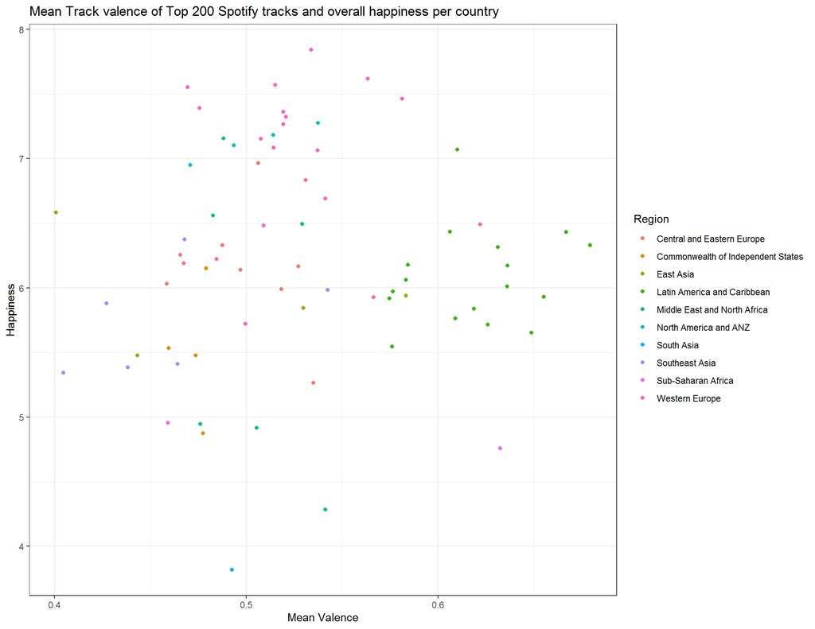

The scatter plot shown above does not have any particularly noticeable trends. There appears to be almost no noticeable relationship between the valence and happiness values in the plot above, as the data points are spread throughout the plot. Interestingly, some regions, such as the ‘Latin America and Caribbean’ region have many data points clustered quite close to one another, which could indicate that there is a regional factor affecting the overall distribution of our variables. To examine this in further detail, we will create separate scatter plots for each region.

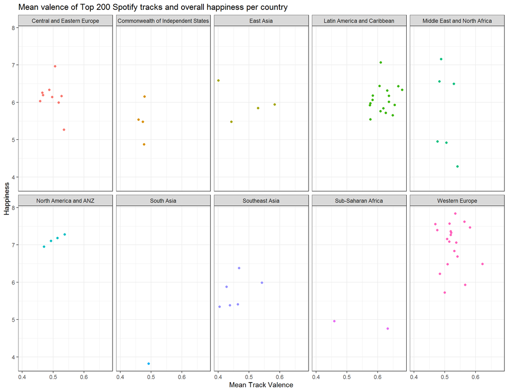

Although the scatter plots which were created above were not promising, it is still possible for there to be a correlation between the average track valence and happiness in these countries. To further investigate this question, we will compute the correlation between these variables using two different correlation metrics; the Pearson correlation coefficient, and Spearman’s rank correlation coefficient.

The Pearson correlation coefficient is a measure of how linear a relationship is between two sets of values. The closer that the Pearson coefficient is to 1 (or -1), the more linear the relationship is. Although the Pearson correlation coefficient is the most commonly-used correlation coefficient, it may not always indicate the presence of a relationship between two variables, if the relationship is non-linear.

[Spearman’s rank correlation coefficient](https://statisticsbyjim.com/basics/spearmans-correlation/) is a distinct measure of the correlation between two numerical variables. Instead of directly measuring how linear the relationship is between the two variables, this metric ranks each of the variables, and then determines whether the rankings of these variables are associated with one another.

The Pearson correlation coefficient between these two variables is 0.0344637, and the Spearman correlation between these variables is 0.0648595. These correlation values are both very close to zero, which signifies that there is not any significant correlation between these variables.

# Conclusions

In this report, our primary guiding question was to determine if there was a correlation between how happy the citizens of a country are and how happy the music which they listen to is.

Based on the scatter plot and the correlation values which we computed in the previous section, it is safe to say that there is a negligible correlation between these values, if there even is any correlation at all.

## Limitations

Overall, the most noticeable limitation of this research project is that the results of this study require an underlying assumption that Spotify users in a given country are representative of the population of that country as a whole.

There are a variety of reasons why this assumption may not be well-founded, from a statistical perspective. Two particularly large issues with this assumption are: - Spotify demographics in a given country may not be representative of the whole population - People in a given country who can afford Spotify Premium may not be representative of the whole population

Additionally, our data collection process suffered from multiple technological limitations, due to the lack of a usable Spotify Charts API, and the rate limits for Spotify’s API. This report would be improved if it were feasible to collect more Spotify Chart data for each country, but this is a difficult process to scale easily, due to the rate limits within the Spotify API.

## Future Steps

Although the data which we collected from the Spotify Charts website and the World Happiness Report did not provide us with a satisfactory answer to our guiding question, it does not mean that these variables are entirely unrelated, and that the data which we have collected is worthless.

There was an unmistakable difference between the happiness index values of the countries which had data available on the Spotify Charts website and the countries which did not have Spotify data. A possible explanation for this difference is that the countries with higher Spotify usage tend to be countries where a large proportion of their citizens have easy access to the Internet, and are able to afford Spotify (if they are Spotify Premium users). The countries which fit this profile may also tend to be the countries which are rated more favourably on the World Happiness Report, likely in part due to their citizens’ access to technology and financial freedom.

A future step for this research could be to incorporate data from the Human Development Index to determine if there are other external factors which can affect Spotify usage in a country as well as the country’s happiness index.